# Trabajo final Estadística Avanzada

Carlos Alberto Murillo M

Luz Stella Florez

Diana Carolina Benjumea

Cindy Guerra

noviembre 28, 2020

# Abstract

Este documento analiza los impactos de las variables macroeconómicas en los costos y gastos de empresas del sector “Extracción de oro y otros metales preciosos”. Para el análisis, se tomaron los datos de los años: 2017, 2018 y 2019. El código de este trabajo se encuentra almacenado en el repositorio de Github: https://github.com/cabymetal/TrabajoFinal_estadisticos_avanzados.

# Objetivos y Lineamientos

Caracterizar las relaciones entre algunos indicadores macroeconómicos y los costos y gastos de ventas de las empresas colombianas vigiladas por la SuperSociedades.

Lineamientos:

1. Con ayuda de un modelo lineal modele cree un modelo o varios modelos que permitan caracterizar la relación entre las variables PIB, Inflación, Desempleo, Tasa de Cambio, Balance Fiscal, Balance en Cuenta Corriente, Tasa de intervención, TRM y los costos y gastos de ventas.
2. Se debe escoger mínimo un tipo de empresas (Clasificación Industrial Internacional Uniforme) que tenga más de 20 empresas y tomar al menos los últimos tres años de información disponible.
3. Se debe evaluar el ajuste y la capacidad predictiva.
4. Se deben explicar todas las transformaciones de variables requeridas por el modelo.
5. Se deben explicar todos los pasos para la construcción de la base de datos: descarga de información, concatenación, etc.
6. Se debe incluir un análisis descriptivo.
7. Se debe incluir un análsis de la razonabilidad de las cifras.
8. Se debe redactar un reporte técnico documentando lo anterior. La sugerencia es utilizar un formato que permita la inclusión de gráficos basados en html o JavaScript (por ejemplo hmtl a partir de Rmarkdown). El código se debe subir a un repositorio Git y referenciarlo en el reporte. El reporte debe incluir una estimación del esfuerzo de las actividades de 1) consolidación de información, 3) transformación de varibles y análisis descriptivo, 4) ajuste y validación de modelos y 5) redacción del reporte.
9. El trabajo se debe subir al canal del curso en Teams y se debe notificar por correo a la dirección judaospi@bancolombia.com.co.
10. La fecha de entrega es el viernes 30 de octubre y el trabajo se puede presentar en equipos de máximo cinco estudiantes.

Para acceder a los datos de costos y gastos de ventas: • Entrar a http://pie.supersociedades.gov.co > MENÚ > Descarga Masiva de Información Descargar la información de los años 2016 a 2019

# Capítulo 1. Lectura de variables de empresa

## Selección de las fuentes de información

Para los datos básicos y financieros de las empresas, tomamos los siguientes archivos de la página de la Supersociedades:

Primera iteración:

Código CIIU seleccionado: G4711

Macrosector: Comercio

Descripción: Comercio al por menor en establecimientos no especializados con surtido compuesto principalmente por alimentos, bebidas o tabaco.

Al realizar los cargues iniciales de información, nos dimos cuenta de que cruzaban muy pocas empresas, el conjunto de datos seleccionado no era suficiente, por lo que decidimos utilizar otro CIIU.

Segunda iteración:

Código CIIU seleccionado: B0722

Descripción: Extracción de oro y otros metales preciosos

## Proceso de carga de los datos

```r
library(tidyverse)
library("readxl")
library("dplyr")
```

1. Cargamos los datos básicos de las empresas

```r
#Revisamos como son nuestros datos para saber si tenemos que realizar algún
#ajuste a la carga
#file.show("./data/datosBasicosComplete.xlsx")

#Como el archivo no tiene forma de tabla al principio, debemos realizar la
#carga, ignorando las primeras filas del archivo.

#Cargar los archivos a un dataframe
pd_datos_basicos <- read_excel("./data/datosBasicosComplete.xlsx",
                               sheet = "Reporte", skip=8, col_types = c("text",
"text", "text", "text", "text","text","text","text","text", "text","text",
"text","text","text","text","text","date","text","date","text","date", "text",
"text"))

pd_datos_basicos %>%
  mutate(`Órgano Societario` = as.factor(`Órgano Societario`),
      `Etapa Situación` = as.factor(`Etapa Situación`)) -> pd_datos_basicos

head(pd_datos_basicos)
```

| NIT | Razón social | Código CIIU | Tipo Societario | Objeto Social | Dirección Notificación Judicial | Ciudad Notificación Judicial | Departamento Notificación Judicial | Teléfono Notificación Judicial | Dirección Domicilio | Ciudad Domicilio | Departamento Domicilio | Apartado Domicilio | E-Mail | Web | Estado | Fecha Estado | Situación | Fecha Situación | Etapa Situación | Fecha Etapa | Nombre Representante Legal | Órgano Societario |
| --- | --- | --- | --- | --- | --- | --- | --- | --- | --- | --- | --- | --- | --- | --- | --- | --- | --- | --- | --- | --- | --- | --- |
| 10018968 | NOREÑA MANRIQUE JAIME ALBERTO | 0 | PERSONA NATURAL | NA | BARRIO EL PROGRESO PEATONAL 1 CASA 156 PISO 1 | ARMENIA | QUINDÍO | 0 | BARRIO EL PROGRESO PEATONAL 1 CASA 156 PISO 1 | ARMENIA | QUINDÍO | 0 | WSAAVEDRA@SBCONSULTORES.COM.CO | NA | EXENTA | 2020-06-30 | ACTIVA | 2020-06-30 | ACTIVA | 2020-06-30 | NA | NO COMERCIANTE |
| 10019295 | PEÑA RAMIREZ JAYSON EN REORGANIZACION EN LIQUIDACIÓN POR ADJUDICACIÓN | H5229 | PERSONA NATURAL | NA | CALLE 3A NRO 34A 21 MZ H CASA 13A | VILLAVICENCIO | META | 6625159 | CALLE 3A NRO 34A 21 MZ H CASA 13A | VILLAVICENCIO | META | NA | JAYSONPE@HOTMAIL.COM | NA | EXENTA | 2016-06-30 | REORGANIZACION | 2018-06-13 | A LIQUIDACION POR ADJUDICACION | 2018-06-13 | NA | COMERCIANTE |
| 10020748 | GONZALEZ SANCHEZ JOHNY FRANCISCO | G4731 | PERSONA NATURAL | NA | BRR. SAN ANTONIO SEC LAS BOMBAS | BOGOTÁ, D.C. | BOGOTÁ, D. C. | 8445933 | BRR. SAN ANTONIO SEC LAS BOMBAS | BOGOTÁ, D.C. | BOGOTÁ, D. C. | NA | JOHNYFR@YAHOO.COM | NA | EXENTA | 2016-07-13 | INACTIVA | 2016-09-02 | INACTIVA | 2016-09-02 | NA | COMERCIANTE |
| 10026101 | RODRIGO JAVIER VILLEGAS CORREA EN REORGANIZACION | L6810 | PERSONA NATURAL | NA | KM 3 VIA MARSELLA TRILLADORA VILLEGAS | PEREIRA | RISARALDA | 3298181 | KM 3 VIA MARSELLA TRILLADORA VILLEGAS | PEREIRA | RISARALDA | NA | RODRIGOJR@VILLEGASYCIA.COM | NA | EXENTA | 2019-05-30 | REORGANIZACION | 2019-09-04 | ADMISION | 2019-09-04 | NA | COMERCIANTE |
| 1002691873 | BUITRAGO GONZALEZ ALEJANDRO | H4923 | PERSONA NATURAL | NA | CARRERA 3 8-05 | SAMACÁ | BOYACÁ | 3183610644 | CARRERA 3 8-05 | SAMACÁ | BOYACÁ | NA | ALEJANDROBUITRAGO2580@GMAIL.COM | NA | EXENTA | 2015-11-30 | INACTIVA | 2016-01-08 | INACTIVA | 2016-01-08 | NA | COMERCIANTE |
| 1005327971 | KAREN JULIETH VIVIESCA SIERRA | M7500 | PERSONA NATURAL | NA | CARRERA 26 NO 30 - 68 BARRIO CAÑAVERAL | FLORIDABLANCA | SANTANDER | 6183884 | CARRERA 26 NO 30 - 68 BARRIO CAÑAVERAL | FLORIDABLANCA | SANTANDER | NA | JANETHVIVIESCAS@HOTMAIL.COM | NA | EXENTA | 2019-07-16 | ACTIVA | 2019-07-16 | ACTIVA | 2019-07-16 | NA | COMERCIANTE |

2. Filtramos los datos del CIIU seleccionado

```r
library(dplyr)

pd_datos_basicos_flt <- pd_datos_basicos[,c("NIT","Razón social","Código CIIU",
      "Ciudad Domicilio","Departamento Domicilio", "Estado","Situación",
      "Órgano Societario", "Etapa Situación")]

names (pd_datos_basicos_flt) = c("NIT","razon_social","CIIU","ciudad",
                                 "departamento", "estado","situacion",
                                 "organo_societario", "etapa_situacion")

pd_datos_basicos_flt <- filter(pd_datos_basicos_flt, CIIU == "B0722" &
                                 situacion == "ACTIVA")

head(pd_datos_basicos_flt)
```

| NIT | razon_social | CIIU | ciudad | departamento | estado | situacion | organo_societario | etapa_situacion |
| --- | --- | --- | --- | --- | --- | --- | --- | --- |
| 800249157 | GRUPO DE BULLET S A S | B0722 | MEDELLÍN | ANTIOQUIA | INSPECCION | ACTIVA | ACTIVIDAD ECONOMICA DIFERENTE | ACTIVA |
| 811002172 | MINERA CROESUS S.A.S | B0722 | MEDELLÍN | ANTIOQUIA | INSPECCION | ACTIVA | ACTIVIDAD ECONOMICA DIFERENTE | ACTIVA |
| 811007250 | NUEVA CALIFORNIA SA | B0722 | MEDELLÍN | ANTIOQUIA | INSPECCION | ACTIVA | ACTIVIDAD ECONOMICA DIFERENTE | ACTIVA |
| 811007252 | COLOMBIA GOLD S.A.S | B0722 | MEDELLÍN | ANTIOQUIA | INSPECCION | ACTIVA | ACTIVIDAD ECONOMICA DIFERENTE | ACTIVA |
| 811041103 | NEGOCIOS MINEROS SA | B0722 | MEDELLÍN | ANTIOQUIA | INSPECCION | ACTIVA | ACTIVIDAD ECONOMICA DIFERENTE | ACTIVA |
| 830012565 | ECO ORO MINERALS CORP | B0722 | BUCARAMANGA | SANTANDER | INSPECCION | ACTIVA | ACTIVIDAD ECONOMICA DIFERENTE | ACTIVA |

3. Cargamos los datos financieros

```r
pd_datos_fin_2017 <- read_excel("./data/Plenas - Individuales2017.xlsx",
                                sheet = "Estado de Resultado Integral" )

pd_datos_fin_2017 <- pd_datos_fin_2017[,c("Nit", "Periodo", "Costo de ventas",
"Costos de distribución", "Gastos de administración", "Otros gastos, por función",
"Costos financieros", "Gasto (ingreso) por impuestos, operaciones continuadas",
"Ingresos de actividades ordinarias", "Otros ingresos", "Ingresos financieros")]


names (pd_datos_fin_2017) = c("NIT", "Periodo", "costo_ventas",
  "costo_distribucion", "gastos_administracion", "otros_gastos",
  "costos_financieros", "gasto_impuestos_operaciones",
  "ingresos_actividades_ordinarias", "otros_ingresos", "ingresos_financieros")


datos_completos_fin <- merge (pd_datos_basicos_flt, pd_datos_fin_2017,
                              by.x="NIT", by.y="NIT")
```

Para efectos del ejercicio, no tomaremos el archivo de 2017, ya que el archivo 2018 tiene los datos de 2017 con la nueva norma.

```r
pd_datos_fin_2018 <- read_excel("./data/Plenas - Individuales2018.xlsx",
                                sheet = "ERI" )

pd_datos_fin_2018 <- pd_datos_fin_2018[,c("Nit", "Periodo", "Costo de ventas",
  "Gastos de ventas", "Gastos de administración", "Otros gastos",
  "Costos financieros", "Ingreso (gasto) por impuestos",
  "Ingresos de actividades ordinarias", "Otros ingresos", "Ingresos financieros")]

names (pd_datos_fin_2018) = c("NIT", "Periodo", "costo_ventas", "gastos_ventas",
  "gastos_administracion", "otros_gastos", "costos_financieros", "gasto_impuestos",
  "ingresos_actividades_ordinarias", "otros_ingresos", "ingresos_financieros" )

datos_completos_2018 <- merge (pd_datos_basicos_flt, pd_datos_fin_2018,
                               by.x="NIT", by.y="NIT")

#Le damos formato a los periodos

datos_completos_2018$Periodo[datos_completos_2018$Periodo == "Periodo Anterior"] <-
  "2017"
datos_completos_2018$Periodo[datos_completos_2018$Periodo == "Periodo Actual"] <-
  "2018"
```

```r
pd_datos_fin_2019 <- read_excel("./data/Plenas - Individuales2019.xlsx",
                                sheet = "ERI" )

#Revisar Costos de distribución
pd_datos_fin_2019 <- pd_datos_fin_2019[,c("Nit", "Periodo", "Costo de ventas",
  "Gastos de administración", "Otros gastos", "Costos financieros",
  "Ingreso (gasto) por impuestos", "Ingresos de actividades ordinarias",
  "Otros ingresos", "Ingresos financieros")]

names (pd_datos_fin_2019) = c("NIT", "Periodo", "costo_ventas",
  "gastos_administracion", "otros_gastos", "costos_financieros",
  "gasto_impuestos", "ingresos_actividades_ordinarias", "otros_ingresos",
  "ingresos_financieros" )

datos_completos <- merge (pd_datos_basicos_flt, pd_datos_fin_2019,
                          by.x="NIT", by.y="NIT")

datos_completos$Periodo[datos_completos$Periodo == "Periodo Actual"] <- "2019"

datos_completos <- filter(datos_completos, Periodo == "2019")
```

```r
#Eliminamos variable diferente a 2019
datos_completos_2018 <- select(datos_completos_2018, -gastos_ventas)


datos_completos = rbind(datos_completos, datos_completos_2018)
datos_completos %>% mutate( razon_social = as.factor(razon_social),
                            CIIU = as.factor(CIIU), ciudad = as.factor(ciudad),
                          departamento = as.factor(departamento),
                          estado =as.factor(estado), Periodo = as.factor(Periodo),
                          situacion = as.factor(situacion)) -> datos_completos
```

Utilizaremos las siguientes variables:

```r
as.data.frame(colnames(datos_completos))
```

| colnames(datos_completos) |
| --- |
| NIT |
| razon_social |
| CIIU |
| ciudad |
| departamento |
| estado |
| situacion |
| organo_societario |
| etapa_situacion |
| Periodo |

[output cut: 8 more lines]

# Capítulo 2. Lectura y consolidación de variables económicas

A continuación se preseenta el proceso que se ejecutó para generar un dataframe con las variables de PIB, Inflación, Desempleo, Balance Fiscal, Balance en Cuenta Corriente, Tasa de intervención, TRM

Es un indicador económico que refleja el valor monetario de todos los bienes y servicios finales producidos por un país o región en un determinado periodo de tiempo, normalmente un año. Se utiliza para medir la riqueza que genera un país. [Datos tomados de aquí](https://datosmacro.expansion.com/pib/colombia). Para cada año se tomó el promedio de los datos diarios.

```r
library(dplyr)
#Los datos son tomados de https://datosmacro.expansion.com/pib/colombia
# vectores
anyo <- c("2016", "2017", "2018", "2019")
PIB_M.E. <- c(289.239, 280.249, 275.999, 255.416)
Var.PIB <- c(3.3, 2.5, 1.4, 2.1)
#Crear dataframe de vectores
PIB <- data.frame(anyo, PIB_M.E., Var.PIB)
head(PIB)
```

|  | anyo | PIB_M.E. | Var.PIB |
| --- | --- | --- | --- |
| 1 | 2016 | 289.239 | 3.3 |
| 2 | 2017 | 280.249 | 2.5 |
| 3 | 2018 | 275.999 | 1.4 |
| 4 | 2019 | 255.416 | 2.1 |

La inflación es un fenómeno que se observa en la economía de un país y está relacionado con el aumento desordenado de los precios de la mayor parte de los bienes y servicios que se comercian en sus mercados, por un periodo de tiempo prolongado. [Datos tomados de aquí](https://es.wikipedia.org/wiki/Anexo:Variaci%C3%B3n_de_la_inflaci%C3%B3n_de_Colombia_desde_1946)

```r
# vectores
anyo <- c("2016", "2017", "2018", "2019")
Inflacion <- c(5.75, 4.09, 3.18, 3.80)
#Crear dataframe de vectores
Inflacion <- data.frame(anyo, Inflacion)
head(Inflacion)
```

|  | anyo | Inflacion |
| --- | --- | --- |
| 1 | 2016 | 5.75 |
| 2 | 2017 | 4.09 |
| 3 | 2018 | 3.18 |
| 4 | 2019 | 3.80 |

Es otra de las variables mas importantes de la macroeconomía, porque afecta directamente el bienestar de las personas. El desempleo es el porcentaje de la fuerza de trabajo que está buscando trabajo activamente y que actualmente se encuentra desempleada. [Datos tomados de aquí](https://www.dane.gov.co/index.php/estadisticas-por-tema/mercado-laboral/empleo-y-desempleo). Se toma el promedio anual

```r
# vectores
anyo <- c("2016", "2017", "2018", "2019")
Desempleo <- c(9.2, 9.4, 9.7, 10.5)
Var.Desempleo <- c(3.36, 1.99, 3.19, 8.25)
#Crear dataframe de vectores
Desempleo <- data.frame(anyo, Desempleo, Var.Desempleo)
head(Desempleo)
```

|  | anyo | Desempleo | Var.Desempleo |
| --- | --- | --- | --- |
| 1 | 2016 | 9.2 | 3.36 |
| 2 | 2017 | 9.4 | 1.99 |
| 3 | 2018 | 9.7 | 3.19 |
| 4 | 2019 | 10.5 | 8.25 |

```r
# vectores
anyo <- c("2016", "2017", "2018", "2019")
GNC <- c(-4, -3.6, -3.1, -2.5)
#Crear dataframe de vectores
GNC <- data.frame(anyo,GNC)
head(GNC)
```

|  | anyo | GNC |
| --- | --- | --- |
| 1 | 2016 | -4.0 |
| 2 | 2017 | -3.6 |
| 3 | 2018 | -3.1 |
| 4 | 2019 | -2.5 |

Es el conjunto de transacciones de intercambio de bienes y servicios, rentas y transferencias (tanto corrientes como de capital), su saldo determina la capacidad o necesidad de financiación de un país. [Datos tomados aquí](https://www.banrep.gov.co/es/estadisticas/balanza-pagos). El dato fue tomado de la cuenta corriente de la balanza de pagos de periodicidad anual

```r
# vectores
anyo <- c("2016", "2017", "2018", "2019")
Balance_Cuenta_Corriente <- c(-13747.75, -13117.66, -10240.88, -12036.18)
#Crear dataframe de vectores
Balance_Cuenta_Corriente <- data.frame(anyo, Balance_Cuenta_Corriente)
head(Balance_Cuenta_Corriente)
```

|  | anyo | Balance_Cuenta_Corriente |
| --- | --- | --- |
| 1 | 2016 | -13747.75 |
| 2 | 2017 | -13117.66 |
| 3 | 2018 | -10240.88 |
| 4 | 2019 | -12036.18 |

Corresponde a la tasa de interés mínima que le cobra el Banco de la República a las entidades financieras por los préstamos que les concede generalmente a un día y, además, sirve como referencia para establecer la tasa de interés máxima que les paga por recibirles dinero que tengan como excedente. [Datos tomados de aquí](https://www.banrep.gov.co/es/estadisticas/tasas-interes-politica-monetaria). Se toma promedio anual de datos diarias

```r
# vectores
anyo <- c("2016", "2017", "2018", "2019")
TIM_promedio<- c(7.10, 6.13, 4.35, 4.25)
#Crear dataframe de vectores
TIM <- data.frame(anyo, TIM_promedio)
head(TIM)
```

|  | anyo | TIM_promedio |
| --- | --- | --- |
| 1 | 2016 | 7.10 |
| 2 | 2017 | 6.13 |
| 3 | 2018 | 4.35 |
| 4 | 2019 | 4.25 |

La tasa de cambio representativa del mercado (TRM) es la cantidad de pesos colombianos por un dólar de los Estados Unidos. La TRM se calcula con base en las operaciones de compra y venta de divisas entre intermediarios financieros que transan en el mercado cambiario colombiano, con cumplimiento el mismo día cuando se realiza la negociación de las divisas.

Actualmente la Superintendencia Financiera de Colombia es la que calcula y certifica diariamente la TRM con base en las operaciones registradas el día hábil inmediatamente anterior. [datos tomados de aquí](https://www.dolar-colombia.com/historico)

```r
#Se leen los datos -
dataset = read.csv('./data/TRM.csv', check.names = FALSE, encoding = "UTF-8",
                   blank.lines.skip = FALSE, dec=",")

#se conservam unicamente las columnas de año y TRM
df = dataset[1]
df['TRM'] = dataset[3]
df$TRM <- as.numeric(as.character(df$TRM))

#Se agrupa bajo la media
media = df
media = media %>%
  group_by(media[1]) %>%
  summarise(across(.cols = everything(), .fns = mean))

#para la mediana
mediana = df
mediana = mediana %>%
  group_by(mediana[1]) %>%
  summarise(across(.cols = everything(), .fns = median))

#Se genera un dataframe con los datos obtenidos
df = media
colnames(df)[2] <- 'TRM_media'
df['TRM_mediana'] <- mediana[2]
df
```

| Anyo | TRM_media | TRM_mediana |
| --- | --- | --- |
| 2016 | 3050.978 | 3003.24 |
| 2017 | 2951.323 | 2942.19 |
| 2018 | 2956.430 | 2898.32 |
| 2019 | 3281.092 | 3277.14 |

Se unen los datos en un solo dataframe

```r
df['PIB_M.E.'] = PIB[2]
df['Var.PIB'] = PIB[3]
df['Inflacion'] = Inflacion[2]
df['Desempleo'] = Desempleo[2]
df['var.Desempleo'] = Desempleo[3]
df['GNC'] = GNC[2]
df['Balance_Cuenta_Corriente'] = Balance_Cuenta_Corriente[2]
df['TIM_promedio'] = TIM[2]
head(df)
```

| Anyo | TRM_media | TRM_mediana | PIB_M.E. | Var.PIB | Inflacion | Desempleo | var.Desempleo | GNC | Balance_Cuenta_Corriente | TIM_promedio |
| --- | --- | --- | --- | --- | --- | --- | --- | --- | --- | --- |
| 2016 | 3050.978 | 3003.24 | 289.239 | 3.3 | 5.75 | 9.2 | 3.36 | -4.0 | -13747.75 | 7.10 |
| 2017 | 2951.323 | 2942.19 | 280.249 | 2.5 | 4.09 | 9.4 | 1.99 | -3.6 | -13117.66 | 6.13 |
| 2018 | 2956.430 | 2898.32 | 275.999 | 1.4 | 3.18 | 9.7 | 3.19 | -3.1 | -10240.88 | 4.35 |
| 2019 | 3281.092 | 3277.14 | 255.416 | 2.1 | 3.80 | 10.5 | 8.25 | -2.5 | -12036.18 | 4.25 |

Se adicionan variables relacionadas con el sector minero, para mejorar la efectividad de los modelos. [Datos tomados de aquí](https://www.banrep.gov.co/es/estadisticas/precios-del-dia-para-el-gramo-oro-plata-y-platino). Para cada año se toma el promedio de los datos diarios

```r
library(dplyr)
#Se leen los datos -
dataset = read_excel('./data/metales.xlsx')
dataset
```

| Anyo | compra_Oro | compra_Plata | compra_Platino | venta_Oro | venta_Plata | venta_Platino |
| --- | --- | --- | --- | --- | --- | --- |
| 2017 | 109846.4 | 1293.691 | 86789.92 | 119398.3 | 1617.114 | 89993.70 |
| 2018 | 110854.5 | 1190.946 | 80470.32 | 120494.0 | 1489.196 | 83440.82 |
| 2019 | 135384.4 | 1369.883 | 87957.89 | 147157.0 | 1712.354 | 91204.78 |

```r
df %>% left_join(dataset, by=c("Anyo") ) -> df
```

# Capítulo 3. Consolidación de la base

En esta sección se unen las dos bases generadas en las fases anteriores en una sola base

```r
library(dplyr)
library(tidyr)
datos_completos%>%mutate(Periodo=as.numeric(as.character(Periodo))) %>%
  inner_join(df, by=c("Periodo" = "Anyo")) %>% replace_na(list(costo_ventas = 0,
  gastos_administracion = 0, otros_gastos=0, costos_financieros=0 ,
  gasto_impuestos=0, ingresos_actividades_ordinarias=0, otros_ingresos = 0,
  ingresos_financieros=0)) -> datos_completos2


datos_completos2 %>% mutate(costos_gastos_totales = gastos_administracion +
                        otros_gastos +gasto_impuestos + costo_ventas,
                        ingresos_totales = ingresos_actividades_ordinarias +
                        ingresos_financieros + otros_ingresos) -> base_modelado

base_modelado <- droplevels(base_modelado)
summary(base_modelado)
```

```
##      NIT                                                razon_social    CIIU
##  Length:82          ANGLOGOLD ASHANTI COLOMBIA S.A.           : 3    B0722:82
##  Class :character   CALDAS GOLD MARMATO S.A.S.                : 3
##  Mode  :character   CONTINENTAL GOLD LIMITED SUCURSAL COLOMBIA: 3
##                     ECO ORO MINERALS CORP                     : 3
##                     EXPLORACIONES CHAPARRAL COLOMBIA SAS      : 3
##                     EXPLORACIONES NORTHERN COLOMBIA S.A.S     : 3
##                     (Other)                                   :64
##           ciudad          departamento        estado    situacion
##  BOGOTÁ, D.C.:26   ANTIOQUIA    :44    INSPECCION:41   ACTIVA:82
##  BUCARAMANGA :12   BOGOTÁ, D. C.:26    VIGILANCIA:41
##  ENVIGADO    : 2   SANTANDER    :12
##  MEDELLÍN    :42
##
##
##
##                      organo_societario etapa_situacion    Periodo
##  ACTIVIDAD ECONOMICA DIFERENTE:82      ACTIVA:82       Min.   :2017
##                                                        1st Qu.:2017
##                                                        Median :2018
##                                                        Mean   :2018
##                                                        3rd Qu.:2019
##                                                        Max.   :2019
##
##   costo_ventas       gastos_administracion  otros_gastos
##  Min.   :        0   Min.   :        0     Min.   :       0
##  1st Qu.:        0   1st Qu.:    15366     1st Qu.:     848
##  Median :        0   Median :   560711     Median :  120317
##  Mean   : 23244524   Mean   : 12272119     Mean   : 3275946
##  3rd Qu.:  6666040   3rd Qu.:  5672411     3rd Qu.: 1736150
##  Max.   :408474390   Max.   :287863704     Max.   :46689684
##
##  costos_financieros gasto_impuestos     ingresos_actividades_ordinarias
##  Min.   :       0   Min.   : -8974634   Min.   :        0
##  1st Qu.:       0   1st Qu.:        0   1st Qu.:        0
##  Median :  168546   Median :     2546   Median :        0
##  Mean   : 2983081   Mean   :  4495562   Mean   : 34205451
##  3rd Qu.: 2383609   3rd Qu.:   141459   3rd Qu.:        0
##  Max.   :52689630   Max.   :131684824   Max.   :954650443
##
```

[output cut: 25 more lines]

```
##  Min.   :109846   Min.   :1191   Min.   :80470   Min.   :119398
##  1st Qu.:109846   1st Qu.:1191   1st Qu.:80470   1st Qu.:119398
##  Median :110854   Median :1294   Median :86790   Median :120494
##  Mean   :118288   Mean   :1283   Mean   :85002   Mean   :128574
##  3rd Qu.:135384   3rd Qu.:1370   3rd Qu.:87958   3rd Qu.:147157
##  Max.   :135384   Max.   :1370   Max.   :87958   Max.   :147157
##
##   venta_Plata   venta_Platino   costos_gastos_totales ingresos_totales
##  Min.   :1489   Min.   :83441   Min.   :     2869     Min.   :        0
##  1st Qu.:1489   1st Qu.:83441   1st Qu.:   528039     1st Qu.:    24364
##  Median :1617   Median :89994   Median :  4175588     Median :   587346
##  Mean   :1604   Mean   :88140   Mean   : 43288150     Mean   : 36327665
##  3rd Qu.:1712   3rd Qu.:91205   3rd Qu.: 26972121     3rd Qu.:  3698197
##  Max.   :1712   Max.   :91205   Max.   :700560590     Max.   :967119965
##
```

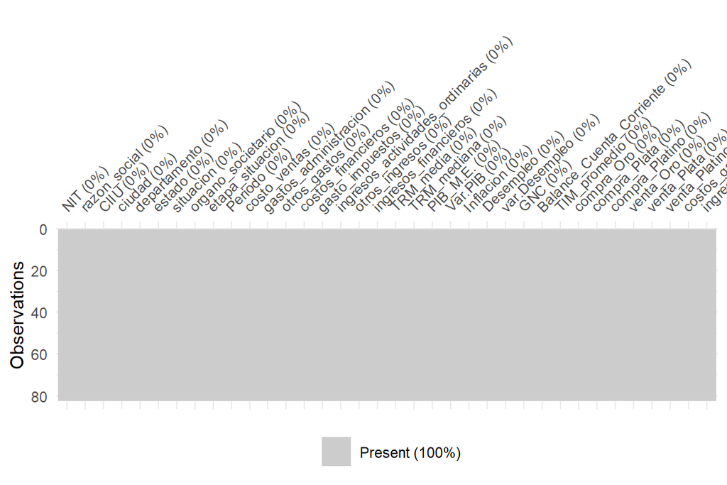

```r
library(visdat)
vis_miss(base_modelado)
```

A continuación se realiza un análisis descriptivo de los datos

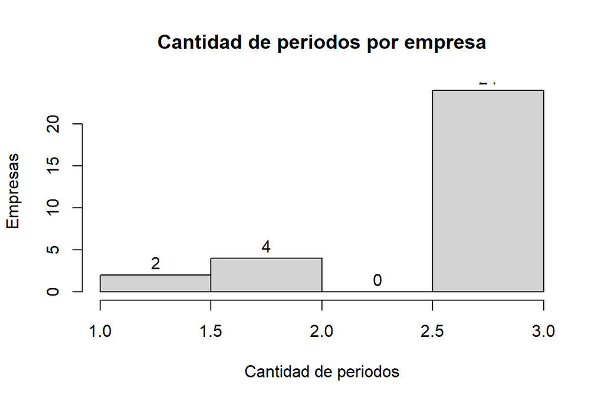

```r
library(ggplot2)
library(tidyr)
library(dplyr)

datosValidar <- base_modelado %>% group_by(NIT, razon_social) %>%
  summarise(total=n())

h <- hist(x = datosValidar$total, main = "Cantidad de periodos por empresa",
          xlab = "Cantidad de periodos", ylab = "Empresas", breaks=3)

text(h$mids,h$counts,labels=h$counts, adj=c(0.5, -0.5))
```

Podemos observar que hay empresas que no tienen los 3 periodos, solo trabajaremos con la empresas que tengan los periodos completos.

```r
base_modelado %>% anti_join(datosValidar %>% filter(total < 3) , by="NIT" ) %>%
  group_by(NIT, razon_social) %>% summarise(total=n()) %>% arrange(desc(total))
```

| NIT | razon_social | total |
| --- | --- | --- |
| 811002172 | MINERA CROESUS S.A.S | 3 |
| 830012565 | ECO ORO MINERALS CORP | 3 |
| 830127076 | ANGLOGOLD ASHANTI COLOMBIA S.A. | 3 |
| 860507991 | SANTIAGO OIL COMPANY | 3 |
| 890114642 | CALDAS GOLD MARMATO S.A.S. | 3 |
| 900039998 | MINERALES ANDINOS DE OCCIDENTE S.A | 3 |
| 900062755 | MINERIA INTEGRAL DE COLOMBIA S.A.S. | 3 |
| 900063262 | SOCIEDAD MINERA DE SANTANDER S.A.S. | 3 |
| 900084407 | GRAMALOTE COLOMBIA LIMITED | 3 |
| 900156833 | MINERA DE COBRE QUEBRADONA SA | 3 |

[output cut: 14 more lines]

```r
base_modelado %>% anti_join(datosValidar %>% filter(total < 3) , by="NIT" ) ->
  base_modelado
base_modelado %>% filter(ingresos_totales == 0) %>% count(NIT) %>%
  filter(n==3) -> datosValidar
base_modelado %>% anti_join(datosValidar, by="NIT" )  ->  base_modelado

datosValidar <- base_modelado %>% group_by(NIT, razon_social) %>%
  summarise(total=n())

table(datosValidar$total)
```

```
##
##  3
## 23
```

Ya podemos ver que tenemos 23 empresas con los 3 periodos. Veamos los ingresos y los costos por departamento.

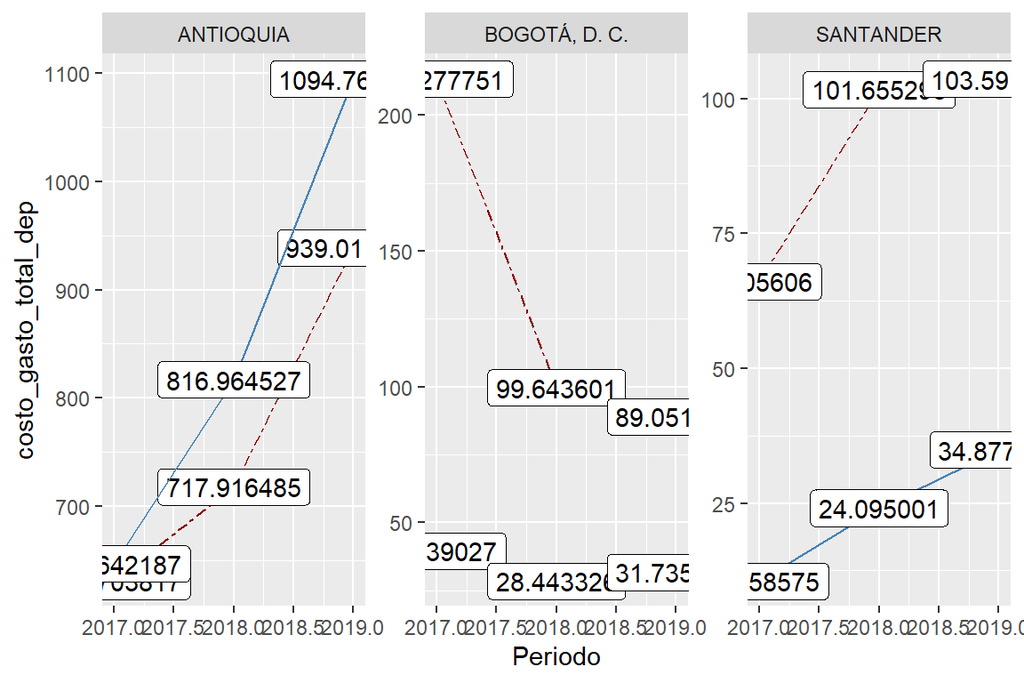

```r
datosValidarDepartamento <- base_modelado %>% group_by(departamento, Periodo) %>%
  summarise(costo_gasto_total_dep = sum(costos_gastos_totales) / 1000000,
  ingresos_totales_dep = sum(ingresos_totales) / 1000000)


ggplot(datosValidarDepartamento, aes(x= Periodo))+
  geom_line(aes(y = costo_gasto_total_dep), color="darkred", linetype="twodash")+
  geom_label(aes(y = costo_gasto_total_dep, label=costo_gasto_total_dep)) +
  geom_line(aes(y = ingresos_totales_dep, label="Ingresos"), color = "steelblue")+
  geom_label(aes(y = ingresos_totales_dep, label=ingresos_totales_dep)) +
  facet_wrap(~departamento, scales ="free_y")
```

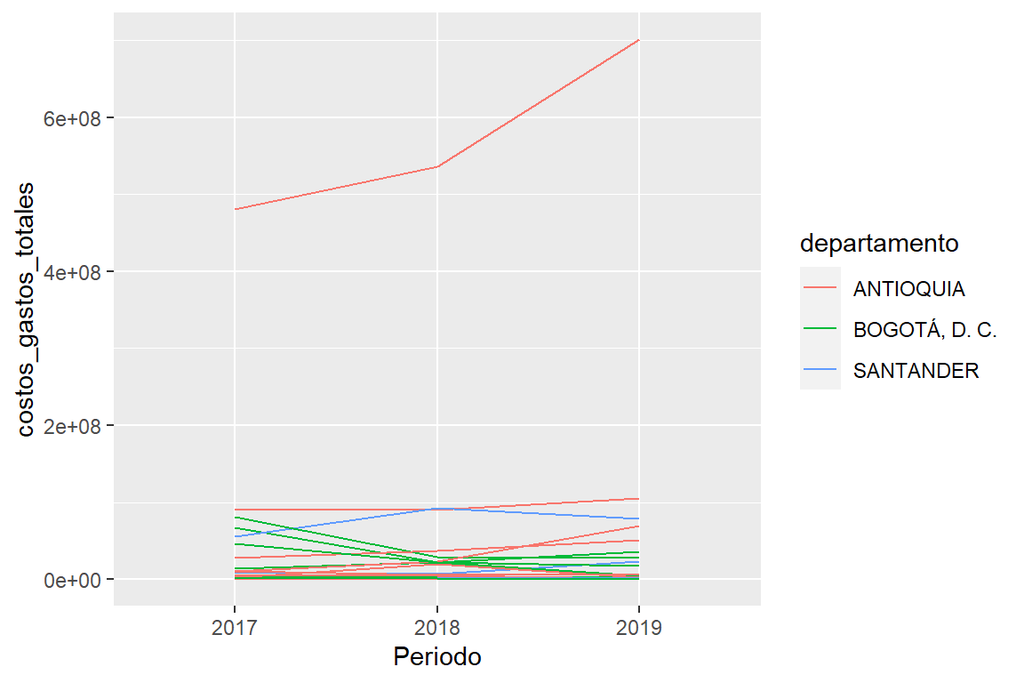

```r
base_modelado$NIT=as.factor(base_modelado$NIT)
base_modelado$Periodo=as.factor(base_modelado$Periodo)

p1=ggplot(base_modelado, aes(y=costos_gastos_totales,x=Periodo,group=NIT,colour=departamento))
p1+geom_line()
```

Se pueden ver algunos comportamientos diferentes por departamento, sin embargo separemos el gráfico para ver mejor:

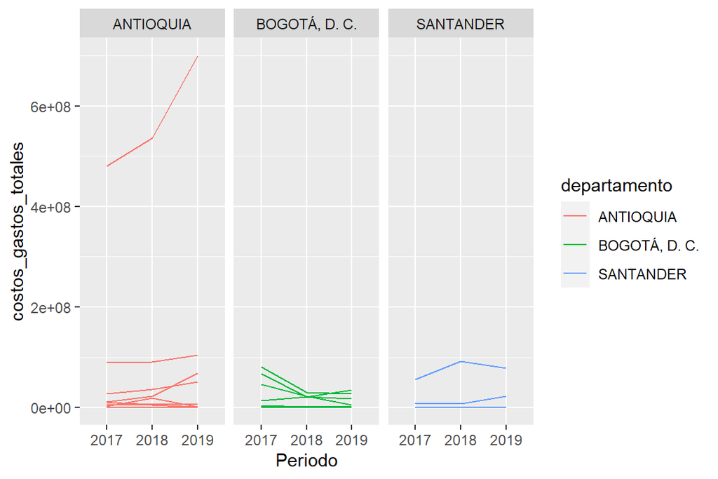

```r
p1+geom_line()+facet_grid(.~departamento)
```

El gráfico anterior nos muestra que cada empresa tiene costos/gastos totales particulares. Adicionalmente, hay una empresa de Medellín que tiene costos/gastos totales mas altos, comparada con las otras. Tratemos de identificar las empresas que tienen un comportamiento más diferente a las demás.

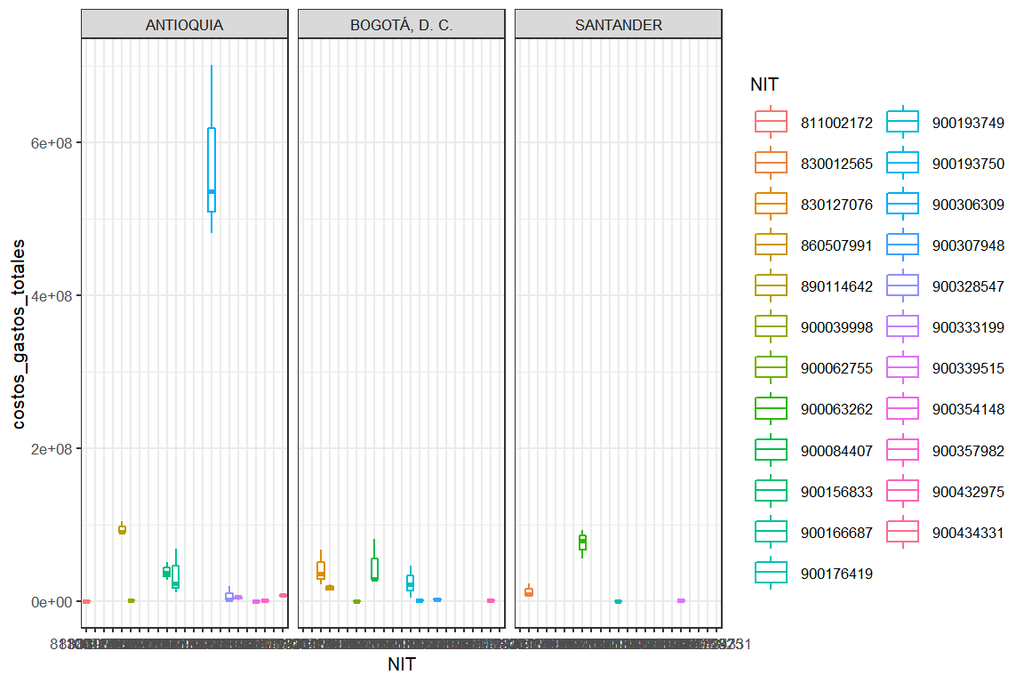

```r
theme_set(theme_bw(base_size = 8))

qplot(NIT, costos_gastos_totales, facets = . ~ departamento,
      colour = NIT, geom = "boxplot", data = base_modelado)
```

Al parecer solo hay 1 empresa que tiene comportamiento de costos/gastos totales mucho mas diferente a las demás.

Realizaremos el ejercicio de eliminar (solo para efectos visuales) la empresa que es mas diferente a las demas.

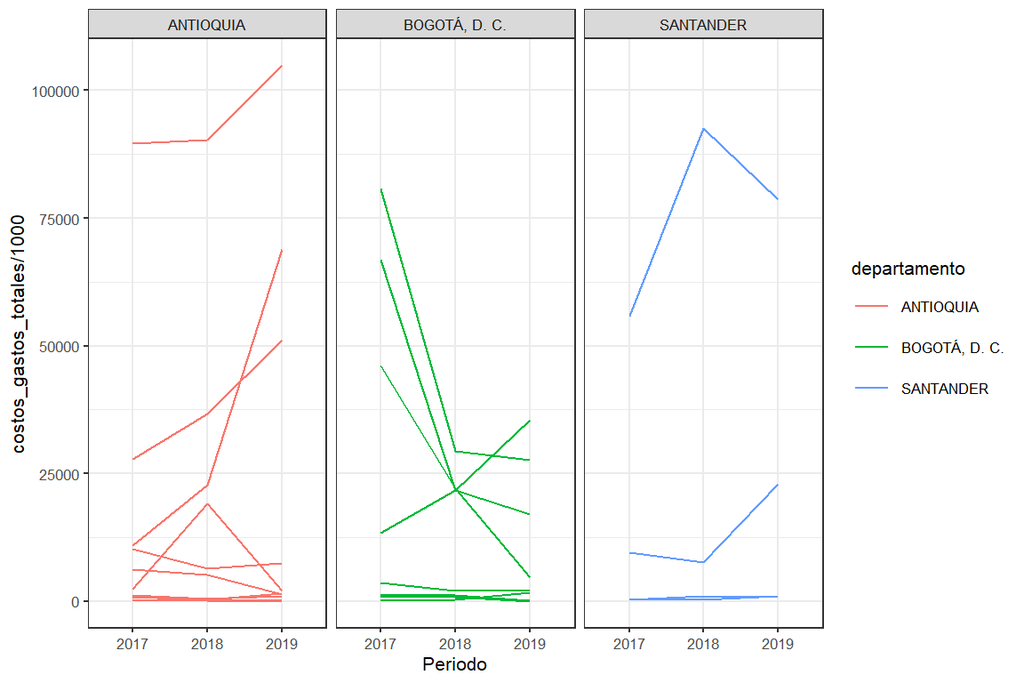

```r
datosValidar <- filter(base_modelado, NIT!=900306309)
p1=ggplot(datosValidar, aes(y=costos_gastos_totales/1000,x=Periodo,group=NIT,
                            colour=departamento))
p1+geom_line()+facet_grid(.~departamento)
```

Confirmamos que los costos/gastos totales son particulares de cada empresa. Cambiemos la escala de los datos y volvamos a graficar, para poder apreciar mejor el comportamiento de las otras empresas que tienen costos/gastos totales mas bajos, pero con el set de empresas completo.

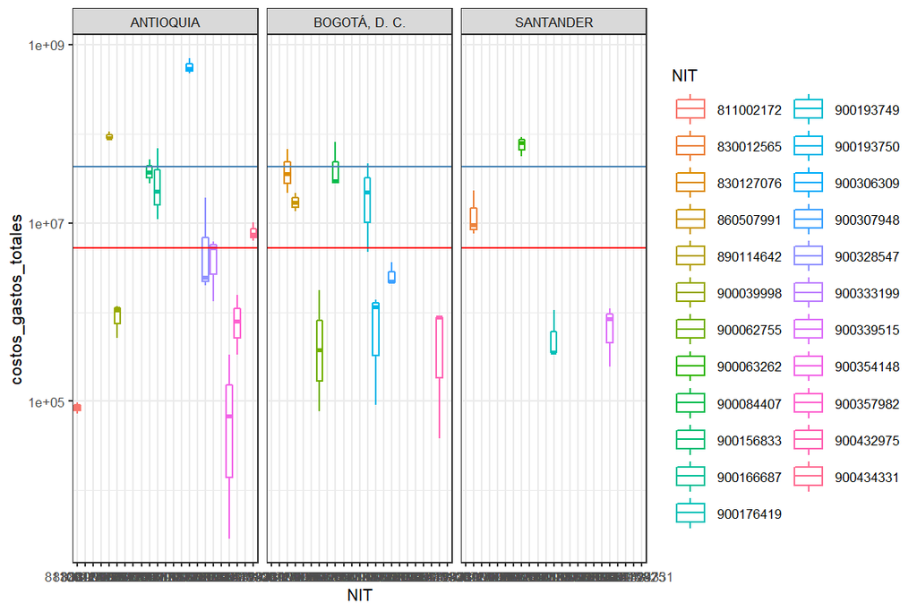

```r
theme_set(theme_bw(base_size = 8))

qplot(NIT, costos_gastos_totales, facets = . ~ departamento,
      colour = NIT, geom = "boxplot", data = base_modelado) +
  scale_y_log10() +
  geom_hline(aes(yintercept = mean(costos_gastos_totales)), color = "steelblue") +

  geom_hline(aes(yintercept = median(costos_gastos_totales)), color = "red")
```

Ahora podemos ver mejor que cada empresa tiene unos costos/gastos totales particulares, así como costos promedio diferentes. Además, encontramos que solamente hay 5 empresas que tienen un comportamiento general en sus costos/gastos totales. Ahora revisemos los costos/gastos totales con el estado.

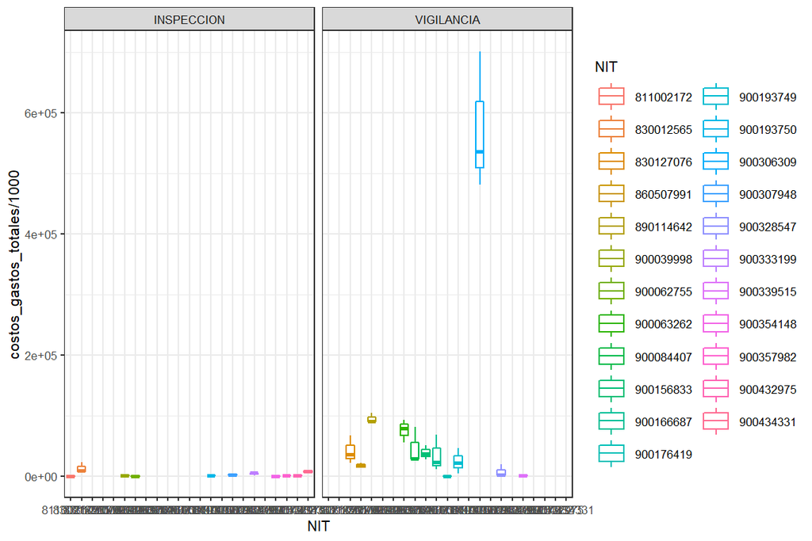

```r
theme_set(theme_bw(base_size = 8))

qplot(NIT, costos_gastos_totales/1000, facets = . ~ estado,
      colour = NIT, geom = "boxplot", data = base_modelado)
```

Podemos ver que las empresas con estado inspección presentan costos/gastos totales menores que las empresas con estado vigilancia.

Veamos ahora la dispersion de nuestra variable objetivo.

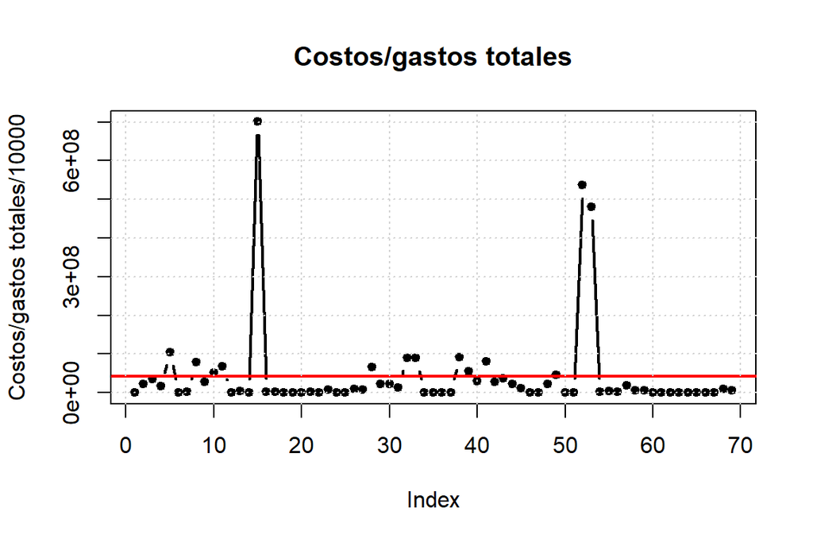

```r
plot(base_modelado$costos_gastos_totales, main="Costos/gastos totales",
    type="b", ylab="Costos/gastos totales/10000", pch= 20, lwd=2)
abline(h=mean(base_modelado$costos_gastos_totales), lwd=2, col= "red")
grid()
```

Con esto confirmamos que la dispersion de los costos/gastos totales no tiene un comportamiento general.

## Estandarización de variables

```r
library(scales)
library(kableExtra)
library(tibble)
base.escalada<- scale(base_modelado[,c(11,12, 13,14,15,16,17,18,19,20,21,22,23,
                    24,25,26,27,28,29,30,31,32,33,34,35,36)],center=T,scale=T)
base.escalada<- as.data.frame(base.escalada)
base.escalada<- rownames_to_column(base.escalada)
tmp <- rownames_to_column(base_modelado %>% select(c("NIT", "razon_social",
  "CIIU", "ciudad","departamento", "estado", "situacion", "organo_societario",
  "etapa_situacion", "Periodo")))
base_modelado <- tmp %>% left_join(base.escalada, by="rowname") %>%
  select(-c("rowname"))
```

# Capítulo 5. Correlaciones

```r
#head(base_modelado)
```

Para el análisis de correlaciones se toman las variables macroeconomicas (PIB, Inflación, Desempleo, GNC, Balance de cuenta corriente y TIM), compa y venta de metales preciosos y se comparan respecto a la variable objetivo.

```
##                          TRM_media TRM_mediana PIB_M.E. Var.PIB Inflacion
## TRM_media                     1.00        0.99    -0.99    0.14      0.19
## TRM_mediana                   0.99        1.00    -0.96    0.26      0.31
## PIB_M.E.                     -0.99       -0.96     1.00    0.00     -0.05
## Var.PIB                       0.14        0.26     0.00    1.00      1.00
## Inflacion                     0.19        0.31    -0.05    1.00      1.00
## Desempleo                     0.97        0.93    -0.99   -0.11     -0.06
## var.Desempleo                 0.99        0.96    -1.00   -0.03      0.02
## GNC                           0.90        0.84    -0.95   -0.31     -0.26
## Balance_Cuenta_Corriente     -0.13       -0.25    -0.02   -1.00     -1.00
## TIM_promedio                 -0.55       -0.45     0.67    0.75      0.71
## compra_Oro                    1.00        0.99    -0.99    0.12      0.17
## compra_Plata                  0.81        0.88    -0.72    0.69      0.73
## compra_Platino                0.61        0.70    -0.49    0.87      0.89
## venta_Oro                     1.00        0.99    -0.99    0.12      0.17
## venta_Plata                   0.81        0.88    -0.72    0.69      0.73
## venta_Platino                 0.61        0.70    -0.49    0.87      0.89
## Var.objetivo                  0.04        0.04    -0.04    0.00      0.01
##                          Desempleo var.Desempleo   GNC Balance_Cuenta_Corriente
## TRM_media                     0.97          0.99  0.90                    -0.13
## TRM_mediana                   0.93          0.96  0.84                    -0.25
## PIB_M.E.                     -0.99         -1.00 -0.95                    -0.02
## Var.PIB                      -0.11         -0.03 -0.31                    -1.00
## Inflacion                    -0.06          0.02 -0.26                    -1.00
## Desempleo                     1.00          1.00  0.98                     0.12
## var.Desempleo                 1.00          1.00  0.96                     0.04
## GNC                           0.98          0.96  1.00                     0.32
## Balance_Cuenta_Corriente      0.12          0.04  0.32                     1.00
## TIM_promedio                 -0.74         -0.68 -0.86                    -0.76
## compra_Oro                    0.97          0.99  0.91                    -0.11
## compra_Plata                  0.64          0.70  0.47                    -0.68
## compra_Platino                0.39          0.47  0.20                    -0.86
## venta_Oro                     0.97          0.99  0.91                    -0.11
## venta_Plata                   0.64          0.70  0.47                    -0.68
## venta_Platino                 0.39          0.47  0.20                    -0.86
## Var.objetivo                  0.04          0.04  0.03                     0.00
##                          TIM_promedio compra_Oro compra_Plata compra_Platino
## TRM_media                       -0.55       1.00         0.81           0.61
## TRM_mediana                     -0.45       0.99         0.88           0.70
## PIB_M.E.                         0.67      -0.99        -0.72          -0.49
```

[output cut: 17 more lines]

```
## PIB_M.E.                     -0.99       -0.72         -0.49        -0.04
## Var.PIB                       0.12        0.69          0.87         0.00
## Inflacion                     0.17        0.73          0.89         0.01
## Desempleo                     0.97        0.64          0.39         0.04
## var.Desempleo                 0.99        0.70          0.47         0.04
## GNC                           0.91        0.47          0.20         0.03
## Balance_Cuenta_Corriente     -0.11       -0.68         -0.86         0.00
## TIM_promedio                 -0.57        0.04          0.32        -0.02
## compra_Oro                    1.00        0.80          0.59         0.04
## compra_Plata                  0.80        1.00          0.96         0.03
## compra_Platino                0.59        0.96          1.00         0.02
## venta_Oro                     1.00        0.80          0.59         0.04
## venta_Plata                   0.80        1.00          0.96         0.03
## venta_Platino                 0.59        0.96          1.00         0.02
## Var.objetivo                  0.04        0.03          0.02         1.00
```

Podemos interpretar que, la correlación entre las varianbles macroeconomicas, compra y venta de metales preciosos con la variable objetivo no son explicativas, si nivel de significancia es cercano a cero. Es decir, no hay una ascociación entre estas variables y la variable objetivo, que nos ayude a predecir o explicar el comportamiento de los costos y gastos totales.

#Visualizar matriz de correlación

Podemos utilizar el comando corrplot. Lo primero es calcular la matriz de correlación y guardarla en un objeto y luego graficarlo. En este caso vamos a graficar los coeficientes.

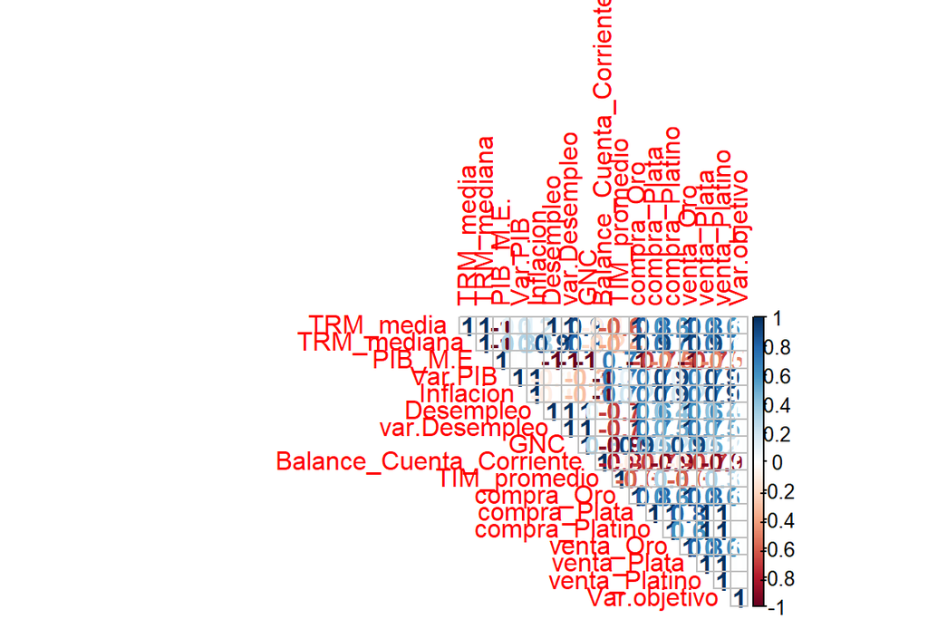

```r
correlacion<-round(cor(base), 1)

corrplot(correlacion, method="number", type="upper")
```

Se realizó el análisis de correlación con el estadístico de Pearson, con las variables originales y estandarizadas con el fin de evidenciar las variables explicativas de la variable objetivo construida, encontrando como resultado la no significancia para explicar el comportamiento de los costos y gastos del sector minero.

A continuación se grafican los datos de la Variable objetivo (costos y gastos totales) con respecto a var.PIB (Variación del PIB)

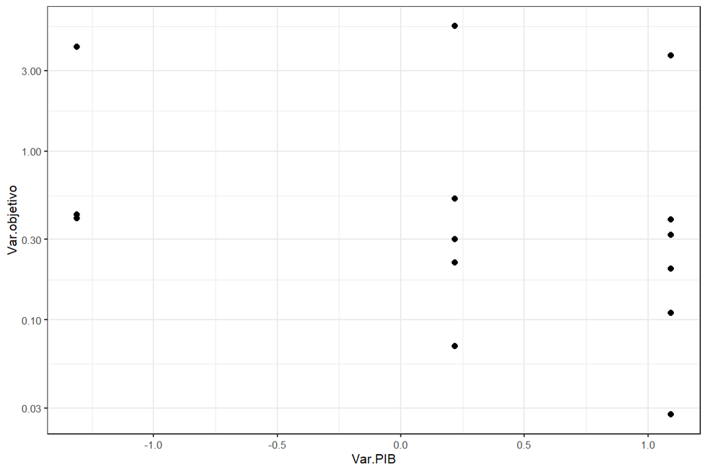

```r
ggplot(base, aes(x=Var.PIB, y=Var.objetivo)) +geom_point()+scale_y_log10()
```

```r
base_modelado %>% select(departamento, estado, Periodo, costos_gastos_totales,
  ciudad, ingresos_totales, NIT, razon_social,otros_ingresos ,
  ingresos_financieros, compra_Oro, compra_Plata, compra_Platino, venta_Oro,
  venta_Plata, venta_Platino) -> base_modelo_lineal

#definir variable de tamaño de la empresa
bussiness_size <- cut(base_modelo_lineal$costos_gastos_totales, breaks=4)
levels(bussiness_size) <- list(small = "(-0.377,0.349]",
                               medium = "(0.349,1.07]",
                               big = "(1.07,1.8]",
                               very_big="(1.8,2.52]")
base_modelo_lineal['tamano_empresa'] <- bussiness_size
base_modelo_lineal %>% filter(NIT != 900306309) -> base_modelo_lineal
head(base_modelo_lineal)
```

|  | departamento | estado | Periodo | costos_gastos_totales | ciudad | ingresos_totales | NIT | razon_social | otros_ingresos | ingresos_financieros | compra_Oro | compra_Plata | compra_Platino | venta_Oro | venta_Plata | venta_Platino | tamano_empresa |
| --- | --- | --- | --- | --- | --- | --- | --- | --- | --- | --- | --- | --- | --- | --- | --- | --- | --- |
| 1 | ANTIOQUIA | INSPECCION | 2019 | -0.36104643 | MEDELLÍN | -0.24581787 | 811002172 | MINERA CROESUS S.A.S | 0.005953155 | -0.3515285 | 1.403075 | 1.151478 | 0.8708067 | 1.403075 | 1.15238 | 0.8708068 | NA |
| 2 | SANTANDER | INSPECCION | 2019 | -0.16782320 | BUCARAMANGA | -0.24842906 | 830012565 | ECO ORO MINERALS CORP | -0.210004581 | -0.3515285 | 1.403075 | 1.151478 | 0.8708067 | 1.403075 | 1.15238 | 0.8708068 | NA |
| 3 | BOGOTÁ, D. C. | VIGILANCIA | 2019 | -0.06283635 | BOGOTÁ, D.C. | -0.25203452 | 830127076 | ANGLOGOLD ASHANTI COLOMBIA S.A. | -0.508192736 | -0.3515285 | 1.403075 | 1.151478 | 0.8708067 | 1.403075 | 1.15238 | 0.8708068 | NA |
| 4 | BOGOTÁ, D. C. | VIGILANCIA | 2019 | -0.21786041 | BOGOTÁ, D.C. | -0.07148885 | 860507991 | SANTIAGO OIL COMPANY | -0.363463888 | -0.1320566 | 1.403075 | 1.151478 | 0.8708067 | 1.403075 | 1.15238 | 0.8708068 | NA |
| 5 | ANTIOQUIA | VIGILANCIA | 2019 | 0.52255596 | MEDELLÍN | 0.52606828 | 890114642 | CALDAS GOLD MARMATO S.A.S. | 0.383638219 | 0.4181071 | 1.403075 | 1.151478 | 0.8708067 | 1.403075 | 1.15238 | 0.8708068 | NA |
| 6 | ANTIOQUIA | INSPECCION | 2019 | -0.35276218 | MEDELLÍN | -0.25203452 | 900039998 | MINERALES ANDINOS DE OCCIDENTE S.A | -0.508192736 | -0.3515285 | 1.403075 | 1.151478 | 0.8708067 | 1.403075 | 1.15238 | 0.8708068 | NA |

# Capítulo 6. Aplicación de modelo

### 6.1. Modelo regresión Lineal - con todas las variables de compra y venta de oro

En este modelo se intenta explicar los costos y gastos en función de las variables de compra y venta de metales preciosos,

```r
library(broom)

mod1 <- lm(costos_gastos_totales ~  compra_Oro + compra_Plata + compra_Platino +
        venta_Oro + venta_Plata + venta_Platino + ingresos_totales,
        data= base_modelo_lineal)
anova(mod1)
```

|  | Df | Sum Sq | Mean Sq | F value | Pr(>F) |
| --- | --- | --- | --- | --- | --- |
| compra_Oro | 1 | 0.001213411 | 0.001213411 | 0.03792054 | 8.462395e-01 |
| compra_Plata | 1 | 0.003590435 | 0.003590435 | 0.11220535 | 7.387779e-01 |
| ingresos_totales | 1 | 1.644292139 | 1.644292139 | 51.38608608 | 1.098488e-09 |
| Residuals | 62 | 1.983924451 | 0.031998781 | NA | NA |

calculamos el resumen del modelo 1

```r
summary(mod1)
```

```
##
## Call:
## lm(formula = costos_gastos_totales ~ compra_Oro + compra_Plata +
##     compra_Platino + venta_Oro + venta_Plata + venta_Platino +
##     ingresos_totales, data = base_modelo_lineal)
##
## Residuals:
##      Min       1Q   Median       3Q      Max
## -0.19751 -0.10238 -0.08597  0.06201  0.56114
##
## Coefficients: (4 not defined because of singularities)
##                  Estimate Std. Error t value Pr(>|t|)
## (Intercept)       0.02387    0.03855   0.619    0.538
## compra_Oro       -0.01201    0.03696  -0.325    0.746
## compra_Plata      0.01249    0.03695   0.338    0.736
## compra_Platino         NA         NA      NA       NA
## venta_Oro              NA         NA      NA       NA
## venta_Plata            NA         NA      NA       NA
## venta_Platino          NA         NA      NA       NA
## ingresos_totales  1.11327    0.15530   7.168  1.1e-09 ***
## ---
## Signif. codes:  0 '***' 0.001 '**' 0.01 '*' 0.05 '.' 0.1 ' ' 1
##
## Residual standard error: 0.1789 on 62 degrees of freedom
## Multiple R-squared:  0.4539, Adjusted R-squared:  0.4275
## F-statistic: 17.18 on 3 and 62 DF,  p-value: 3.124e-08
```

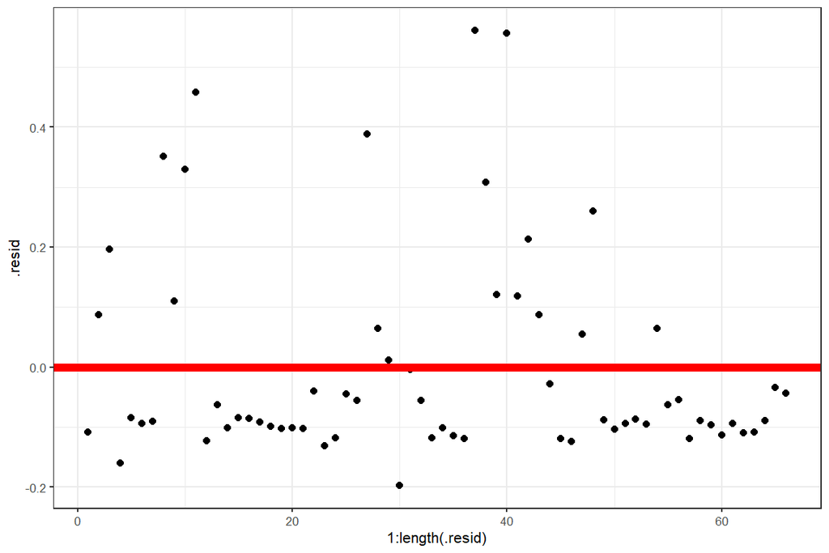

```r
a <- augment(mod1)
ggplot(a, aes(x=1:length(.resid), y=.resid))+
  geom_point() +
  geom_hline(yintercept = 0, lwd=2, col= "red")
```

Evaluación de los modelos: AIC BIC y R2.

El AIC NO es una prueba de hipótesis sobre el ajuste de un modelo sino más bien un criterio paramétrico comparativo entre modelos y representa por esto una herramienta para selección de modelos. Dado un conjunto de datos, es posible encontrar varios modelos que se ajustan a ellos. La idea es ranquearlos de acuerdo al AIC.

```r
glance(mod1)
```

| r.squared | adj.r.squared | sigma | statistic | p.value | df | logLik | AIC | BIC | deviance | df.residual | nobs |
| --- | --- | --- | --- | --- | --- | --- | --- | --- | --- | --- | --- |
| 0.4539187 | 0.4274954 | 0.178882 | 17.17874 | 3.124263e-08 | 3 | 22.00112 | -34.00225 | -23.05398 | 1.983924 | 62 | 66 |

### 6.1. Modelo regresión Lineal

```r
library(broom)
library("broom.mixed")

mod1 <- lm(costos_gastos_totales ~  estado, data= base_modelo_lineal)
anova(mod1)
```

|  | Df | Sum Sq | Mean Sq | F value | Pr(>F) |
| --- | --- | --- | --- | --- | --- |
| estado | 1 | 1.181955 | 1.18195532 | 30.86215 | 5.741617e-07 |
| Residuals | 64 | 2.451065 | 0.03829789 | NA | NA |

calculamos el resumen del modelo 1

```r
summary(mod1)
```

```
##
## Call:
## lm(formula = costos_gastos_totales ~ estado, data = base_modelo_lineal)
##
## Residuals:
##      Min       1Q   Median       3Q      Max
## -0.29051 -0.09070 -0.01786  0.02839  0.59167
##
## Coefficients:
##                  Estimate Std. Error t value Pr(>|t|)
## (Intercept)      -0.33676    0.03407  -9.885 1.66e-14 ***
## estadoVIGILANCIA  0.26764    0.04818   5.555 5.74e-07 ***
## ---
## Signif. codes:  0 '***' 0.001 '**' 0.01 '*' 0.05 '.' 0.1 ' ' 1
##
## Residual standard error: 0.1957 on 64 degrees of freedom
## Multiple R-squared:  0.3253, Adjusted R-squared:  0.3148
## F-statistic: 30.86 on 1 and 64 DF,  p-value: 5.742e-07
```

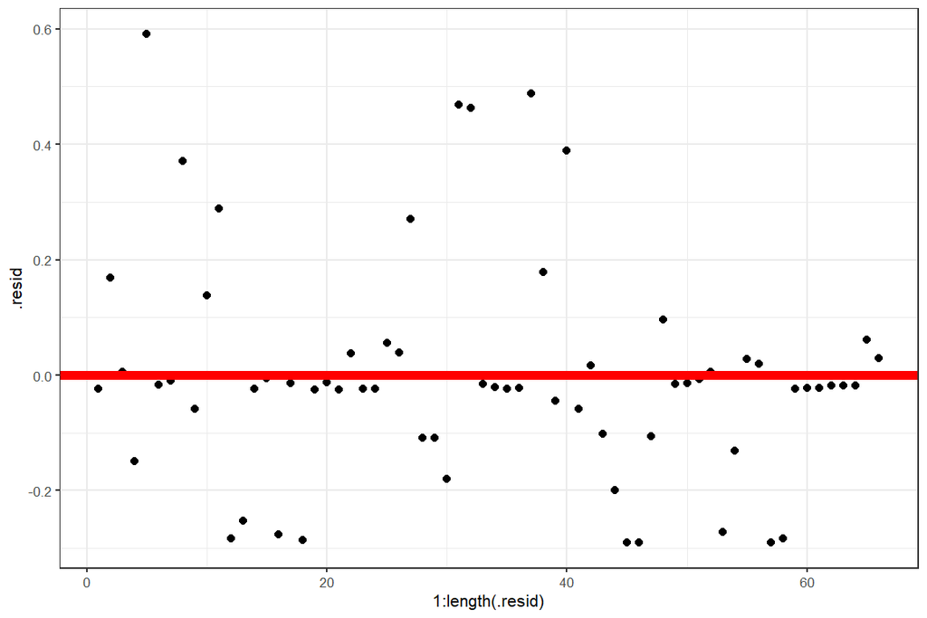

```r
a <- augment(mod1)
ggplot(a, aes(x=1:length(.resid), y=.resid))+
  geom_point() +
  geom_hline(yintercept = 0, lwd=2, col= "red")
```

Evaluación de los modelos: AIC, BIC y R2

```r
glance(mod1)
```

| r.squared | adj.r.squared | sigma | statistic | p.value | df | logLik | AIC | BIC | deviance | df.residual | nobs |
| --- | --- | --- | --- | --- | --- | --- | --- | --- | --- | --- | --- |
| 0.3253368 | 0.3147952 | 0.1956985 | 30.86215 | 5.741617e-07 | 1 | 15.02342 | -24.04683 | -17.47787 | 2.451065 | 64 | 66 |

### 6.2. Modelo Regresión lineal Sin efectos aleatorios

```r
mod2 <- lm(costos_gastos_totales ~ estado + ingresos_totales,
           data= base_modelo_lineal)
anova(mod2)
```

|  | Df | Sum Sq | Mean Sq | F value | Pr(>F) |
| --- | --- | --- | --- | --- | --- |
| estado | 1 | 1.1819553 | 1.18195532 | 51.00379 | 1.131280e-09 |
| ingresos_totales | 1 | 0.9911111 | 0.99111113 | 42.76847 | 1.258389e-08 |
| Residuals | 63 | 1.4599540 | 0.02317387 | NA | NA |

```r
summary(mod2)
```

```
##
## Call:
## lm(formula = costos_gastos_totales ~ estado + ingresos_totales,
##     data = base_modelo_lineal)
##
## Residuals:
##      Min       1Q   Median       3Q      Max
## -0.25499 -0.04208 -0.01584  0.02511  0.47185
##
## Coefficients:
##                  Estimate Std. Error t value Pr(>|t|)
## (Intercept)       -0.1120     0.0434  -2.580   0.0122 *
## estadoVIGILANCIA   0.1881     0.0394   4.773 1.12e-05 ***
## ingresos_totales   0.9080     0.1389   6.540 1.26e-08 ***
## ---
## Signif. codes:  0 '***' 0.001 '**' 0.01 '*' 0.05 '.' 0.1 ' ' 1
##
## Residual standard error: 0.1522 on 63 degrees of freedom
## Multiple R-squared:  0.5981, Adjusted R-squared:  0.5854
## F-statistic: 46.89 on 2 and 63 DF,  p-value: 3.375e-13
```

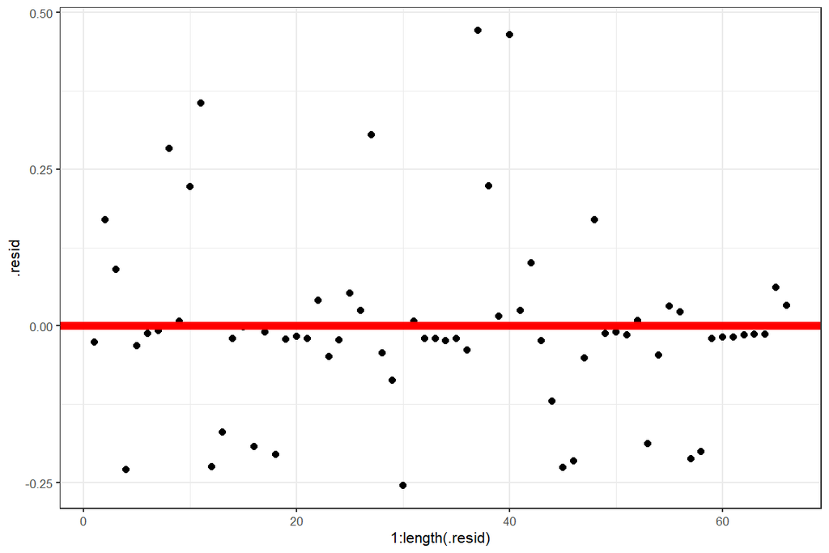

```r
a <- augment(mod2)
ggplot(a, aes(x=1:length(.resid), y=.resid))+
  geom_point() +
  geom_hline(yintercept = 0, lwd=2, col= "red")
```

Evaluación de los modelos: AIC, BIC y R2

```r
glance(mod2)
```

| r.squared | adj.r.squared | sigma | statistic | p.value | df | logLik | AIC | BIC | deviance | df.residual | nobs |
| --- | --- | --- | --- | --- | --- | --- | --- | --- | --- | --- | --- |
| 0.5981432 | 0.5853858 | 0.1522297 | 46.88613 | 3.37479e-13 | 2 | 32.1213 | -56.2426 | -47.48398 | 1.459954 | 63 | 66 |

### 6.3. Modelo lineal con intercepto aleatorio

```r
library(lme4)
mod4 <- lmer(costos_gastos_totales ~ ingresos_totales + (1|departamento),
             data= base_modelo_lineal)

anova(mod4)
```

|  | npar | Sum Sq | Mean Sq | F value |
| --- | --- | --- | --- | --- |
| ingresos_totales | 1 | 1.645172 | 1.645172 | 52.96734 |

```r
summary(mod4)
```

```
## Linear mixed model fit by REML ['lmerMod']
## Formula: costos_gastos_totales ~ ingresos_totales + (1 | departamento)
##    Data: base_modelo_lineal
##
## REML criterion at convergence: -36.1
##
## Scaled residuals:
##     Min      1Q  Median      3Q     Max
## -1.0611 -0.5900 -0.4911  0.3066  3.2155
##
## Random effects:
##  Groups       Name        Variance  Std.Dev.
##  departamento (Intercept) 6.354e-23 7.971e-12
##  Residual                 3.106e-02 1.762e-01
## Number of obs: 66, groups:  departamento, 3
##
## Fixed effects:
##                  Estimate Std. Error t value
## (Intercept)       0.02375    0.03796   0.626
## ingresos_totales  1.11269    0.15289   7.278
##
## Correlation of Fixed Effects:
##             (Intr)
## ingrss_ttls 0.821
## convergence code: 0
## boundary (singular) fit: see ?isSingular
```

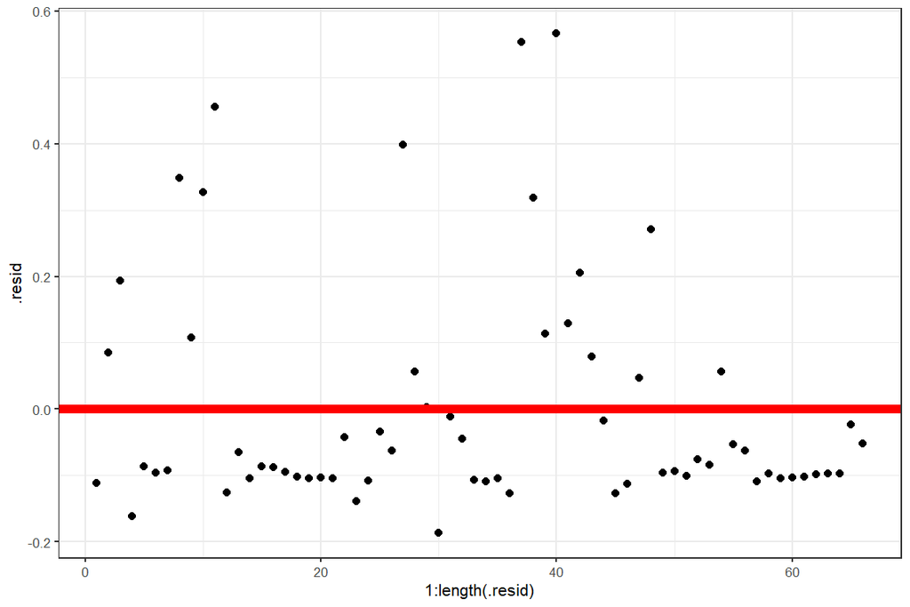

```r
a <- broom.mixed::augment(mod4)
ggplot(a, aes(x=1:length(.resid), y=.resid))+
  geom_point() +
  geom_hline(yintercept = 0, lwd=2, col= "red")
```

```r
broom.mixed::glance(mod4)
```

| sigma | logLik | AIC | BIC | REMLcrit | df.residual |
| --- | --- | --- | --- | --- | --- |
| 0.1762388 | 18.04953 | -28.09907 | -19.34045 | -36.09907 | 62 |